# A8_metabar

Qiuhan Zhang

2023-03-08

[My Repository](https://github.com/qiuhan1008/Assignment8.git)

```r
#import dataset
library(readr)
Mydata<- read_csv("FloristicSurvey.csv")
#change population to character
Mydata$Population <- as.character(Mydata$Population)
head(Mydata)
```

```
## # A tibble: 6 × 44
##   Quadr…¹ Popul…² Locat…³ Roset…⁴ Bolting Budding Bud_Flw Flower Flw_Sil Silli…⁵
##   <chr>   <chr>   <chr>     <dbl>   <dbl>   <dbl>   <dbl>  <dbl>   <dbl>   <dbl>
## 1 7o3     7       o             0       0       0       0      0       0       0
## 2 7o1     7       o             0       0       0       0      0       0       0
## 3 7o2     7       o             0       0       0       0      0       0       0
## 4 7i3     7       i            14       8     157       0      0       0       0
## 5 7i2     7       i             3      18     184       0      0       0       0
## 6 7i1     7       i             0       3     122       0      0       0       0
## # … with 34 more variables: Claytonia_virginiana <dbl>, Anemone_hepatica <dbl>,
## #   Grass_tuft <dbl>, Trillium_grandifolium <dbl>,
## #   `Erythronium(trout lily)` <dbl>, Acer_saccharum <dbl>,
## #   Dicentra_cucularia <dbl>, Bloodroot <dbl>, Gallium_aparine <dbl>,
## #   Ulmus_americana <dbl>, Unknown_1 <dbl>, Unknown_2 <dbl>,
## #   `Unknown_3(rannunculaceae)` <dbl>, Unknown_4 <dbl>,
## #   Dryopteris_marginalis <dbl>, Ostrich_fern <dbl>, …
```

# Bray-Curtis dissimilarity

```r
#install.packages("vegan")
library(vegan)
Subdata <- subset(Mydata[, 11:44])
row.names(Subdata) <- Mydata$Quadrate
```

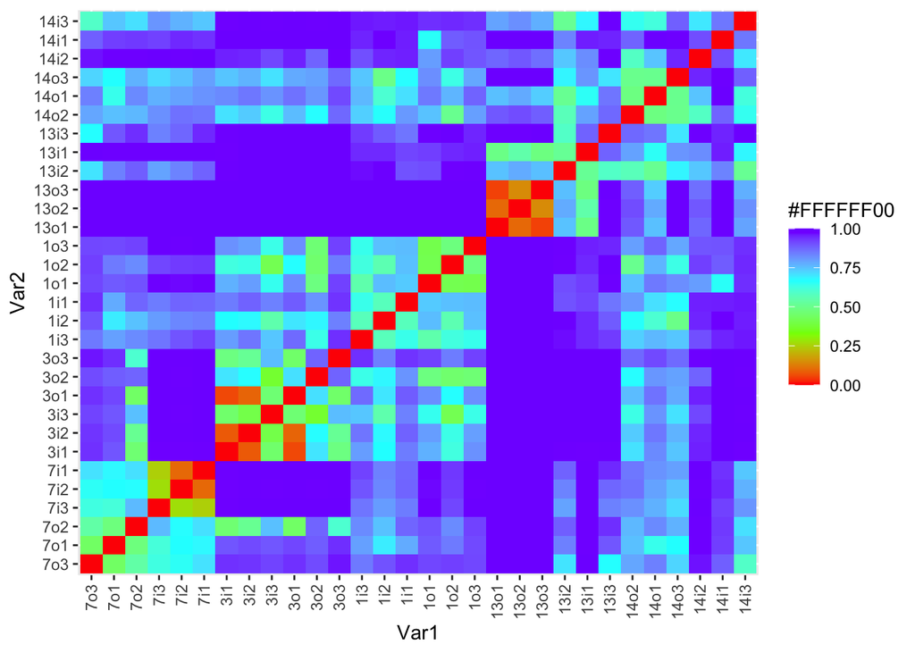

```r
S_dist<- vegdist(Subdata, method = "bray", binary = F)
SDistMat <- as.matrix(S_dist)
library(reshape2)
SDat <- melt(SDistMat)
library(ggplot2)
ggplot(SDat, aes(Var1, Var2, fill = value)) +
  geom_tile() +
  scale_fill_gradientn(colours = rainbow(4), alpha(0.8)) +
  theme(axis.text.x = element_text(angle = 90, hjust = 1, vjust = 0.5))
```

Fig.1.The plot demonstrates the degree of similarity / dissimilarity in the abundance of species across sample locations at QUBS. Color ranges from red to purple represent values from 0 to 1. From 13o1 - 13o3, there’s no presence of garlic mustard.

##NJ Tree grouped presence of garlic mustard

```r
library(ape)
library(ggtree)
```

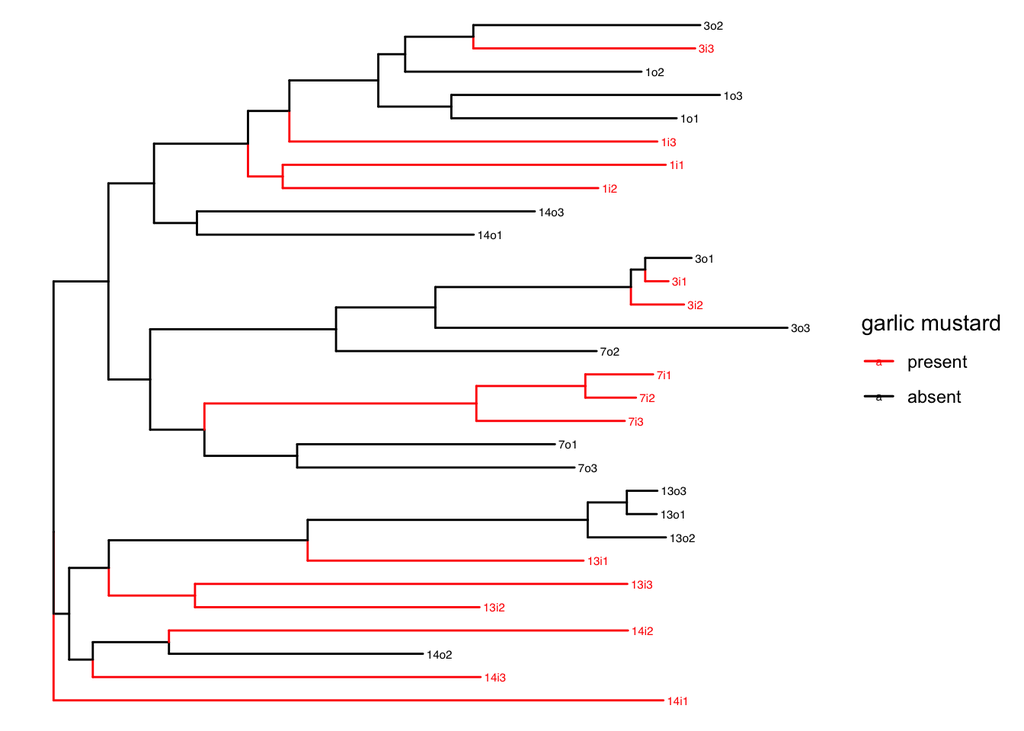

```r
STreeNJ <- nj(S_dist)
# use gsub to highlight the presentence of garlic mustard as to see if it affects the species abundance.
Pres <- gsub(".*([o|i]).*", "\\1", STreeNJ$tip.label)
# group 'tip.labels' by their corresponding treatment
TreatGroups <- split(STreeNJ$tip.label, Pres)
# use the groupOTU function to apply the grouping information for plotting
SDTcol <- groupOTU(STreeNJ, TreatGroups)
# plot
ggtree(SDTcol, layout = "rectangular", aes(color = group)) +
  geom_tiplab(size = 2) +
  theme(legend.position="right") +
  scale_colour_manual(name = "garlic mustard",
                      values = c("red", "black"),
                      labels = c("present", "absent"))
```

```r
## NJ Tree grouped by populations
```

Fig.2.The neighbour-joining tree clustered sample depends on the species abundance. The presence of garlic mustard were labeled by red and absent is in black.

[figure not shown]

```r
# use gsub to highlight the presentence of garlic mustard as to see if it affects the species abundance.
Pop <- gsub("(.*)[o|i].*", "\\1", STreeNJ$tip.label)
# group 'tip.labels' by their corresponding treatment
PopGroups <- split(STreeNJ$tip.label, Pop)
# use the groupOTU function to apply the grouping information for plotting
SDTcol2 <- groupOTU(STreeNJ, PopGroups)
# plot
ggtree(SDTcol2, layout = "rectangular", aes(color = group)) +
  geom_tiplab(size = 2) +
  theme(legend.position="right") +
  scale_colour_manual(name = "population",
                      values = rainbow(5),
                      labels = c("1", "3", "7", "13", "14"))
```

Figure 3. This tree clusters samples based on the similarity of their species abundance. The 5 sampling populations are colorered.